# Optimal Treatment Analysis

## Outcome Variable

**Outcome Variable:** whz

## Predictor Variables

**Intervention Variable:** parity

**Adjustment Set:**

- arm
- W_mage
- meducyrs
- feducyrs
- hhwealth_quart
- W_mhtcm
- vagbrth
- W_nrooms
- impsan
- delta_W_mage
- delta_meducyrs
- delta_feducyrs
- delta_hhwealth_quart
- delta_W_mhtcm
- delta_vagbrth
- delta_W_nrooms
- delta_impsan

## Stratifying Variables

The analysis was stratified on these variable(s):

- agecat
- studyid
- country

## Data Summary

| agecat | studyid | country | parity | n_cell | n |
| --- | --- | --- | --- | --- | --- |
| Birth | ki1000304b-SAS-CompFeed | INDIA | 1 | 41 | 166 |
| Birth | ki1000304b-SAS-CompFeed | INDIA | 2 | 44 | 166 |
| Birth | ki1000304b-SAS-CompFeed | INDIA | 3+ | 81 | 166 |
| Birth | ki1101329-Keneba | GAMBIA | 1 | 142 | 1292 |
| Birth | ki1101329-Keneba | GAMBIA | 2 | 133 | 1292 |
| Birth | ki1101329-Keneba | GAMBIA | 3+ | 1017 | 1292 |
| Birth | ki1126311-ZVITAMBO | ZIMBABWE | 1 | 5561 | 12915 |
| Birth | ki1126311-ZVITAMBO | ZIMBABWE | 2 | 3882 | 12915 |
| Birth | ki1126311-ZVITAMBO | ZIMBABWE | 3+ | 3472 | 12915 |
| Birth | ki1135781-COHORTS | GUATEMALA | 1 | 94 | 756 |
| Birth | ki1135781-COHORTS | GUATEMALA | 2 | 118 | 756 |
| Birth | ki1135781-COHORTS | GUATEMALA | 3+ | 544 | 756 |
| Birth | ki1135781-COHORTS | INDIA | 1 | 641 | 3855 |
| Birth | ki1135781-COHORTS | INDIA | 2 | 982 | 3855 |
| Birth | ki1135781-COHORTS | INDIA | 3+ | 2232 | 3855 |
| Birth | ki1135781-COHORTS | PHILIPPINES | 1 | 640 | 2899 |
| Birth | ki1135781-COHORTS | PHILIPPINES | 2 | 657 | 2899 |
| Birth | ki1135781-COHORTS | PHILIPPINES | 3+ | 1602 | 2899 |
| Birth | kiGH5241-JiVitA-3 | BANGLADESH | 1 | 4604 | 15692 |
| Birth | kiGH5241-JiVitA-3 | BANGLADESH | 2 | 5539 | 15692 |
| Birth | kiGH5241-JiVitA-3 | BANGLADESH | 3+ | 5549 | 15692 |
| 6 months | ki1000304b-SAS-CompFeed | INDIA | 1 | 392 | 1334 |
| 6 months | ki1000304b-SAS-CompFeed | INDIA | 2 | 302 | 1334 |
| 6 months | ki1000304b-SAS-CompFeed | INDIA | 3+ | 640 | 1334 |
| 6 months | ki1000304b-SAS-FoodSuppl | INDIA | 1 | 72 | 373 |
| 6 months | ki1000304b-SAS-FoodSuppl | INDIA | 2 | 84 | 373 |
| 6 months | ki1000304b-SAS-FoodSuppl | INDIA | 3+ | 217 | 373 |
| 6 months | ki1017093b-PROVIDE | BANGLADESH | 1 | 211 | 582 |
| 6 months | ki1017093b-PROVIDE | BANGLADESH | 2 | 212 | 582 |
| 6 months | ki1017093b-PROVIDE | BANGLADESH | 3+ | 159 | 582 |

[output cut: 51 more lines]

The following strata were considered:

- agecat: 24 months, studyid: ki1017093b-PROVIDE, country: BANGLADESH
- agecat: 24 months, studyid: ki1066203-TanzaniaChild2, country: TANZANIA, UNITED REPUBLIC OF
- agecat: 24 months, studyid: ki1101329-Keneba, country: GAMBIA
- agecat: 24 months, studyid: ki1113344-GMS-Nepal, country: NEPAL
- agecat: 24 months, studyid: ki1126311-ZVITAMBO, country: ZIMBABWE
- agecat: 24 months, studyid: ki1135781-COHORTS, country: GUATEMALA
- agecat: 24 months, studyid: ki1135781-COHORTS, country: INDIA
- agecat: 24 months, studyid: ki1135781-COHORTS, country: PHILIPPINES
- agecat: 24 months, studyid: kiGH5241-JiVitA-3, country: BANGLADESH
- agecat: 6 months, studyid: ki1000304b-SAS-CompFeed, country: INDIA
- agecat: 6 months, studyid: ki1000304b-SAS-FoodSuppl, country: INDIA
- agecat: 6 months, studyid: ki1017093b-PROVIDE, country: BANGLADESH
- agecat: 6 months, studyid: ki1066203-TanzaniaChild2, country: TANZANIA, UNITED REPUBLIC OF
- agecat: 6 months, studyid: ki1101329-Keneba, country: GAMBIA
- agecat: 6 months, studyid: ki1113344-GMS-Nepal, country: NEPAL
- agecat: 6 months, studyid: ki1126311-ZVITAMBO, country: ZIMBABWE
- agecat: 6 months, studyid: ki1135781-COHORTS, country: GUATEMALA
- agecat: 6 months, studyid: ki1135781-COHORTS, country: INDIA
- agecat: 6 months, studyid: ki1135781-COHORTS, country: PHILIPPINES
- agecat: 6 months, studyid: kiGH5241-JiVitA-3, country: BANGLADESH
- agecat: Birth, studyid: ki1000304b-SAS-CompFeed, country: INDIA
- agecat: Birth, studyid: ki1101329-Keneba, country: GAMBIA
- agecat: Birth, studyid: ki1126311-ZVITAMBO, country: ZIMBABWE
- agecat: Birth, studyid: ki1135781-COHORTS, country: GUATEMALA
- agecat: Birth, studyid: ki1135781-COHORTS, country: INDIA
- agecat: Birth, studyid: ki1135781-COHORTS, country: PHILIPPINES
- agecat: Birth, studyid: kiGH5241-JiVitA-3, country: BANGLADESH

### Dropped Strata

Some strata were dropped due to rare outcomes:

- agecat: 24 months, studyid: ki1066203-TanzaniaChild2, country: TANZANIA, UNITED REPUBLIC OF

## Methods Detail

We’re interested in the causal parameters $E[Y_a]$ for all values of $a \in \mathcal{A}$. These parameters represent the mean outcome if, possibly contrary to fact, we intervened to set all units to have $A=a$. Under the randomization and positivity assumptions, these are identified by the statistical parameters $\psi_a=E_W[E_{Y|A,W}(Y|A=a,W)]$. In addition, we’re interested in the mean of $Y$, $E[Y]$ under no intervention (the observed mean). We will estimate these parameters by using SuperLearner to fit the relevant likelihood factors – $E_{Y|A,W}(Y|A=a,W)$ and $p(A=a|W)$, and then updating our likelihood fit using a joint TMLE.

For unadjusted analyses ($W=\{\}$), initial likelihoods were estimated using Lrnr_glm to estimate the simple $E(Y|A)$ and Lrnr_mean to estimate $p(A)$. For adjusted analyses, a small library containing Lrnr_glmnet, Lrnr_xgboost, and Lrnr_mean was used.

Having estimated these parameters, we will then use the delta method to estimate relative risks and attributable risks relative to a prespecified baseline level of $A$.

# Results Detail

## Results Plots

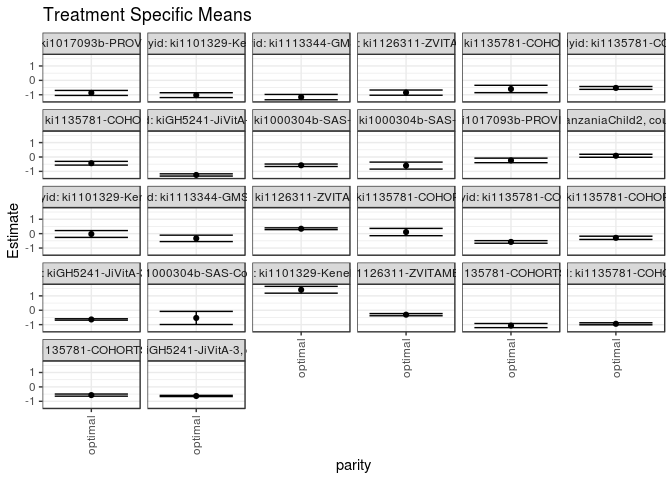

## Results Table

### Parameter: TSM

| agecat | studyid | country | intervention_level | baseline_level | estimate | ci_lower | ci_upper |
| --- | --- | --- | --- | --- | --- | --- | --- |
| Birth | ki1000304b-SAS-CompFeed | INDIA | optimal | observed | -0.5351641 | -0.9904736 | -0.0798546 |
| Birth | ki1101329-Keneba | GAMBIA | optimal | observed | 1.4233762 | 1.1866852 | 1.6600671 |
| Birth | ki1126311-ZVITAMBO | ZIMBABWE | optimal | observed | -0.3070226 | -0.3821743 | -0.2318710 |
| Birth | ki1135781-COHORTS | GUATEMALA | optimal | observed | -1.0637740 | -1.2079443 | -0.9196038 |
| Birth | ki1135781-COHORTS | INDIA | optimal | observed | -0.9411260 | -1.0100897 | -0.8721622 |
| Birth | ki1135781-COHORTS | PHILIPPINES | optimal | observed | -0.5713318 | -0.6452992 | -0.4973643 |
| Birth | kiGH5241-JiVitA-3 | BANGLADESH | optimal | observed | -0.6322466 | -0.6727421 | -0.5917511 |
| 6 months | ki1000304b-SAS-CompFeed | INDIA | optimal | observed | -0.5757433 | -0.6607003 | -0.4907862 |
| 6 months | ki1000304b-SAS-FoodSuppl | INDIA | optimal | observed | -0.5974217 | -0.8397404 | -0.3551029 |
| 6 months | ki1017093b-PROVIDE | BANGLADESH | optimal | observed | -0.2384848 | -0.3977525 | -0.0792171 |
| 6 months | ki1066203-TanzaniaChild2 | TANZANIA, UNITED REPUBLIC OF | optimal | observed | 0.0853103 | -0.0193659 | 0.1899866 |
| 6 months | ki1101329-Keneba | GAMBIA | optimal | observed | -0.0247013 | -0.2629155 | 0.2135130 |
| 6 months | ki1113344-GMS-Nepal | NEPAL | optimal | observed | -0.3304336 | -0.5531211 | -0.1077461 |
| 6 months | ki1126311-ZVITAMBO | ZIMBABWE | optimal | observed | 0.3395949 | 0.2771984 | 0.4019913 |
| 6 months | ki1135781-COHORTS | GUATEMALA | optimal | observed | 0.1084753 | -0.1452525 | 0.3622031 |
| 6 months | ki1135781-COHORTS | INDIA | optimal | observed | -0.5767200 | -0.6665119 | -0.4869280 |
| 6 months | ki1135781-COHORTS | PHILIPPINES | optimal | observed | -0.2921431 | -0.4058352 | -0.1784509 |
| 6 months | kiGH5241-JiVitA-3 | BANGLADESH | optimal | observed | -0.6397818 | -0.6876655 | -0.5918981 |
| 24 months | ki1017093b-PROVIDE | BANGLADESH | optimal | observed | -0.8730434 | -1.0458446 | -0.7002422 |
| 24 months | ki1101329-Keneba | GAMBIA | optimal | observed | -1.0273102 | -1.1946897 | -0.8599308 |
| 24 months | ki1113344-GMS-Nepal | NEPAL | optimal | observed | -1.1628551 | -1.3487720 | -0.9769382 |
| 24 months | ki1126311-ZVITAMBO | ZIMBABWE | optimal | observed | -0.8518855 | -1.0317908 | -0.6719802 |
| 24 months | ki1135781-COHORTS | GUATEMALA | optimal | observed | -0.5995547 | -0.8544881 | -0.3446214 |
| 24 months | ki1135781-COHORTS | INDIA | optimal | observed | -0.5256408 | -0.6256748 | -0.4256068 |
| 24 months | ki1135781-COHORTS | PHILIPPINES | optimal | observed | -0.4339286 | -0.5636014 | -0.3042557 |
| 24 months | kiGH5241-JiVitA-3 | BANGLADESH | optimal | observed | -1.2478956 | -1.3255913 | -1.1702000 |

### Parameter: E(Y)

| agecat | studyid | country | intervention_level | baseline_level | estimate | ci_lower | ci_upper |
| --- | --- | --- | --- | --- | --- | --- | --- |
| Birth | ki1000304b-SAS-CompFeed | INDIA | observed | observed | -0.2697590 | -0.5399211 | 0.0004030 |
| Birth | ki1101329-Keneba | GAMBIA | observed | observed | 1.7138545 | 1.6262621 | 1.8014469 |
| Birth | ki1126311-ZVITAMBO | ZIMBABWE | observed | observed | -0.5152877 | -0.5411394 | -0.4894359 |
| Birth | ki1135781-COHORTS | GUATEMALA | observed | observed | -1.0621429 | -1.1631387 | -0.9611471 |
| Birth | ki1135781-COHORTS | INDIA | observed | observed | -0.9498080 | -0.9874148 | -0.9122013 |
| Birth | ki1135781-COHORTS | PHILIPPINES | observed | observed | -0.7427251 | -0.7890855 | -0.6963647 |
| Birth | kiGH5241-JiVitA-3 | BANGLADESH | observed | observed | -0.7238886 | -0.7437224 | -0.7040548 |
| 6 months | ki1000304b-SAS-CompFeed | INDIA | observed | observed | -0.6657084 | -0.8024377 | -0.5289791 |
| 6 months | ki1000304b-SAS-FoodSuppl | INDIA | observed | observed | -0.9946381 | -1.1114079 | -0.8778682 |
| 6 months | ki1017093b-PROVIDE | BANGLADESH | observed | observed | -0.2083706 | -0.2927992 | -0.1239419 |
| 6 months | ki1066203-TanzaniaChild2 | TANZANIA, UNITED REPUBLIC OF | observed | observed | 0.0797179 | 0.0266621 | 0.1327737 |
| 6 months | ki1101329-Keneba | GAMBIA | observed | observed | -0.1874118 | -0.2456850 | -0.1291387 |
| 6 months | ki1113344-GMS-Nepal | NEPAL | observed | observed | -0.6047987 | -0.6909649 | -0.5186325 |
| 6 months | ki1126311-ZVITAMBO | ZIMBABWE | observed | observed | 0.3048076 | 0.2787350 | 0.3308802 |
| 6 months | ki1135781-COHORTS | GUATEMALA | observed | observed | 0.1940810 | 0.1226351 | 0.2655269 |
| 6 months | ki1135781-COHORTS | INDIA | observed | observed | -0.7068611 | -0.7417800 | -0.6719423 |
| 6 months | ki1135781-COHORTS | PHILIPPINES | observed | observed | -0.2938433 | -0.3352064 | -0.2524802 |
| 6 months | kiGH5241-JiVitA-3 | BANGLADESH | observed | observed | -0.5932502 | -0.6127743 | -0.5737261 |
| 24 months | ki1017093b-PROVIDE | BANGLADESH | observed | observed | -0.8879412 | -0.9708680 | -0.8050144 |
| 24 months | ki1101329-Keneba | GAMBIA | observed | observed | -0.7834078 | -0.8357743 | -0.7310414 |
| 24 months | ki1113344-GMS-Nepal | NEPAL | observed | observed | -1.1315863 | -1.2192240 | -1.0439487 |
| 24 months | ki1126311-ZVITAMBO | ZIMBABWE | observed | observed | -1.1802133 | -1.2803837 | -1.0800428 |
| 24 months | ki1135781-COHORTS | GUATEMALA | observed | observed | -0.2813755 | -0.3354674 | -0.2272835 |
| 24 months | ki1135781-COHORTS | INDIA | observed | observed | -0.6564729 | -0.6914450 | -0.6215007 |
| 24 months | ki1135781-COHORTS | PHILIPPINES | observed | observed | -0.6099592 | -0.6467541 | -0.5731643 |
| 24 months | kiGH5241-JiVitA-3 | BANGLADESH | observed | observed | -1.2971774 | -1.3204904 | -1.2738644 |

### Parameter: PAR

| agecat | studyid | country | intervention_level | baseline_level | estimate | ci_lower | ci_upper |
| --- | --- | --- | --- | --- | --- | --- | --- |
| Birth | ki1000304b-SAS-CompFeed | INDIA | optimal | observed | 0.2654051 | 0.0366219 | 0.4941882 |
| Birth | ki1101329-Keneba | GAMBIA | optimal | observed | 0.2904783 | 0.0701771 | 0.5107796 |
| Birth | ki1126311-ZVITAMBO | ZIMBABWE | optimal | observed | -0.2082650 | -0.2799355 | -0.1365945 |
| Birth | ki1135781-COHORTS | GUATEMALA | optimal | observed | 0.0016312 | -0.1006347 | 0.1038971 |
| Birth | ki1135781-COHORTS | INDIA | optimal | observed | -0.0086821 | -0.0673893 | 0.0500252 |
| Birth | ki1135781-COHORTS | PHILIPPINES | optimal | observed | -0.1713933 | -0.2326326 | -0.1101541 |
| Birth | kiGH5241-JiVitA-3 | BANGLADESH | optimal | observed | -0.0916420 | -0.1301106 | -0.0531734 |
| 6 months | ki1000304b-SAS-CompFeed | INDIA | optimal | observed | -0.0899651 | -0.1965938 | 0.0166636 |
| 6 months | ki1000304b-SAS-FoodSuppl | INDIA | optimal | observed | -0.3972164 | -0.6400697 | -0.1543631 |
| 6 months | ki1017093b-PROVIDE | BANGLADESH | optimal | observed | 0.0301142 | -0.1133871 | 0.1736156 |
| 6 months | ki1066203-TanzaniaChild2 | TANZANIA, UNITED REPUBLIC OF | optimal | observed | -0.0055924 | -0.0972426 | 0.0860577 |
| 6 months | ki1101329-Keneba | GAMBIA | optimal | observed | -0.1627106 | -0.3953355 | 0.0699144 |
| 6 months | ki1113344-GMS-Nepal | NEPAL | optimal | observed | -0.2743651 | -0.4892235 | -0.0595067 |
| 6 months | ki1126311-ZVITAMBO | ZIMBABWE | optimal | observed | -0.0347873 | -0.0928119 | 0.0232373 |
| 6 months | ki1135781-COHORTS | GUATEMALA | optimal | observed | 0.0856057 | -0.1626345 | 0.3338459 |
| 6 months | ki1135781-COHORTS | INDIA | optimal | observed | -0.1301412 | -0.2140159 | -0.0462664 |
| 6 months | ki1135781-COHORTS | PHILIPPINES | optimal | observed | -0.0017002 | -0.1104178 | 0.1070173 |
| 6 months | kiGH5241-JiVitA-3 | BANGLADESH | optimal | observed | 0.0465316 | 0.0032621 | 0.0898011 |
| 24 months | ki1017093b-PROVIDE | BANGLADESH | optimal | observed | -0.0148978 | -0.1661922 | 0.1363965 |
| 24 months | ki1101329-Keneba | GAMBIA | optimal | observed | 0.2439024 | 0.0822521 | 0.4055528 |
| 24 months | ki1113344-GMS-Nepal | NEPAL | optimal | observed | 0.0312688 | -0.1359391 | 0.1984766 |
| 24 months | ki1126311-ZVITAMBO | ZIMBABWE | optimal | observed | -0.3283278 | -0.4956711 | -0.1609844 |
| 24 months | ki1135781-COHORTS | GUATEMALA | optimal | observed | 0.3181793 | 0.0713114 | 0.5650471 |
| 24 months | ki1135781-COHORTS | INDIA | optimal | observed | -0.1308321 | -0.2251676 | -0.0364965 |
| 24 months | ki1135781-COHORTS | PHILIPPINES | optimal | observed | -0.1760306 | -0.2995585 | -0.0525027 |
| 24 months | kiGH5241-JiVitA-3 | BANGLADESH | optimal | observed | -0.0492818 | -0.1225887 | 0.0240252 |